# Search For A Data Job

Ricky Zhao

12/14/2020

# Search for a Data Job

Nowadays, we have two different types of title for Data Job, one is Statistician, one is Data Scientist. What are the difference between these two kind of title?

Here are some questions to be answered in this project:  
1. Descriptions: Is there any difference in the Job Descriptions?  
2. Experience: How many years of experience are expected by companies?  
3. Location: Where to find a Data Job?  
4. Location: Word Count/Cloud between different location (MA/CA)  
5. Company: Who is providing Data Job?  
6. Mapping the Jobs

# Extract data from Indeed

In the website of Indeed: https://www.indeed.com/, we can search for Job information with keywords.  
Extract data with keywords **Statistician** and **Data Scientist**, get information of Job Title, Company, Location, Job Link, Job Description.  
Take Statistician as example:

Title

Company

Location

Link

Description

Biostatistician I

Harvard University

Boston, MA

https://www.indeed.com/rc/clk?jk=ce417b75baa8b168&fccid=5507a64404691526&vjs=3

Job Code RS0356 Statistician I Sub-Unit - Department Center for Biostatistics in AIDS Research Time Status Full-time Salary Grade 056 Union 00 - Non Union, Exempt or Temporary Appointment End Date 30-Nov-2027 Pre-Employment Screening Education, Identity EEO Statement We are an equal opportunity employer and all qualified applicants will receive consideration for employment without regard to race, color, religion, sex, national origin, disability status, protected veteran status, gender identity, sexual orientation, pregnancy and pregnancy-related conditions, or any other characteristic protected by law.

WIC Statistician

Health & Human Services Comm

Austin, TX

https://www.indeed.com/rc/clk?jk=09e6243ecc698d21&fccid=113517153f849886&vjs=3

Perform highly advanced (senior-level) statistical analysis work for the Vendor Management & Operations Unit within the Special Supplemental Nutrition Program for Women, Infants, and Children (WIC) Program. Oversee development and testing of data sets to target fraud, waste, and abuse among WIC vendors. Develop test data gathering designs, sampling techniques, and analytical methods for analysis of WIC program vendor data. Collaborate with Information Resources and WIC staff on data gathering for USDA and WIC studies. Responsible for statistical methodology for identifying high risk vendors. Conduct statistical analysis of vendor reports and other documentation to identify trends in vendor compliance. Design complex reports and databases using various systems and software (for example, SQL, PowerBI, Tableau, Statistica and SPSS). Utilize Microsoft Office, including Excel, for complex projects requiring extensive knowledge of the software and its functions. Collaborate with WIC staff on preparation of WIC program and vendor reports. Analyze data for preparation of various WIC program and vendor reports to ensure data integrity. Build business cases from data. Communicate both verbally and in writing with a wide variety of internal and external stakeholders. Work under minimal supervision, with extensive latitude for the use of initiative and independent judgment. Essential Job Functions: Attends work on a regular and predictable schedule in accordance with agency leave policy and performs other duties as assigned.

1. Oversee development and testing of data sets, which includes database development, database query tests, validation of data, and development of methodologies that will detect fraud, waste, and abuse among WIC vendors. Requires the utilization of various systems and software (SQL, PowerBI, Tableau, Statistica, SPSS, and Microsoft Office, including Excel, etc). (15%)
2. Responsible for statistical methodology for identifying high risk vendors, which includes being part of a project team, interfacing with staff and vendors, data and requirements gathering, trend analysis, retail industry research, and conducting statistical tests. (15%)
3. Develop test data gathering designs, sampling techniques, and analytical methods for analysis of WIC program vendor data and build business cases from data. (15%)
4. Conduct statistical analysis of vendor reports and other documentation to identify trends in vendor compliance. (15%)
5. Analyze grocer retail data for preparation of monthly, quarterly, ad-hoc and yearly report requirements. Data must be validated and formatted to specific templates. Analysis includes trend, forecast, financial, statically based and supported, and industry cluster related. (10%)
6. Oversee development of monthly, quarterly, yearly, and ad-hoc reporting. Responsible for working with WIC staff to determine reporting needs, prepare templates, then recommend action. (10%)
7. Collaborate with WIC staff, and internal and external stakeholders on data gathering for reporting purposes to ensure data integrity. (5%)
8. Serve as statistical Subject Matter Expert for the Unit and WIC and provide expert advice on national and regional WIC studies. This includes expert data analysis, comprehension of reported information, and recommended action. (5%)
9. Communicate clearly both verbally and in writing with a wide variety of internal and external stakeholders. (5%)
10. Perform other duties as assigned including but not limited to actively participating and/or serving in a supporting role to meet the agency’s obligations for disaster response and/or recovery or Continuity of Operations (COOP) activation. Such participation may require an alternate shift pattern assignment and/or locations. (5%)Knowledge Skills Abilities: Knowledge of: Statistics and mathematics Statistical methods and formulas Research techniques, and of the sources and availability of information Fraud, waste, and abuse statistical methodologies Quality assurance procedures WIC Program, and WIC federal regulations and guidelines Basic economic principles

Skill in: Organizing, managing, and prioritizing tasks and schedules Report preparation of a scientific topic for internal and external stakeholders Retrieving and analyzing data using, for example, SQL, PowerBI, Tableau, Statistica, SPSS Using Microsoft Office, including Excel Developing and designing sampling techniques and statistical methodologies Data analysis methods and statistical analysis, statistical tools and databases Organizing, coordinating, and directing statistical research projects and reports Evaluating statistical data, conducting qualitative and quantitative analysis Directing the development of data collection methods Presenting and explaining analytical results clearly and concisely Building a business case from data

Ability to: Communicate clearly and effectively both verbally and in writing to internal and external stakeholders Prioritize and plan assignments, and handle multiple projects in a fast paced environment Work effectively under pressure Establish and maintain positive and effective working relationships with staff at all levels of the organization, and internal and external stakeholders Understand,interpret and apply department and agency rules, regulations, policies and procedures Plan, assign, and/or direct the work of others Registration or Licensure Requirements: None Initial Selection Criteria:At least two (2) years of experience in data and/or statistical analysis At least two (2) years of experience in report development Experience with Structured Query Language (SQL)

PREFERRED: Minimum of a Bachelor’s Degree with major coursework in statistics, data analytics, mathematics, computer science, or a related field Experience working for the State of Texas Additional Information: REQ 471388

To be considered for an interview, applicants must demonstrate a clear match to all Initial Selection Criteria under each job in the Summary of Experience sections of the application. RESUMES WILL NOT BE CONSIDERED. Please complete all fields in the application. The salary on this job posting reflects the minimum and maximum allowed, however, budget considerations often result in salary offers at the minimum of the posted range. Internal applicants are encouraged to check the HR manual for any changes to their current salary.

All applicants chosen to participate in the “virtual” face-to-face interview process will be required to complete an on-camera skills assessment to demonstrate proficiencies associated with this role at the time of the interview. All applicants participating in the virtual “face to face” interview process must also have access to a computer, the internet, Microsoft Teams, Microsoft Word, and Microsoft Excel. Only applicants selected for an interview will be notified of final selection. At the time of posting, this position is working from home but in normal times, it will be office-based. The person selected for this position must have internet access for working from home.

Military occupation(s) that relate to the initial selection criteria and registration or licensure requirements for this position may include, but are not limited to: 47N, MGT15, 8825, 61AX. All active duty military, reservists, guardsmen, and veterans are encouraged to apply if qualified to fill this position. For more information, see the Texas State Auditor’s Military Crosswalk at http://www.hr.sao.state.tx.us/Compensation/JobDescriptions.aspx. MOS Code: 47N, MGT15, 8825, 61AXHHS agencies use E-Verify. You must bring your I-9 documentation with you on your first day of work.I-9 Form - Click here to download the I-9 form.In compliance with the Americans with Disabilities Act (ADA), HHS agencies will provide reasonable accommodation during the hiring and selection process for qualified individuals with a disability. If you need assistance completing the on-line application, contact the HHS Employee Service Center at 1-888-894-4747. If you are contacted for an interview and need accommodation to participate in the interview process, please notify the person scheduling the interview.

STATISTICIAN

Precision Consulting

New York, NY

https://www.indeed.com/rc/clk?jk=170fc25cffd33e85&fccid=f9fe675c31a6b8de&vjs=3

STATISTICIAN The main responsibility will be to support our clients with larger, more complex statistical analyses. All applicants will need to be comfortable designing and drafting a valid statistical methodology (specifying the sample, population, instrumentation, data collection and analysis procedures, etc.), running the analyses using standard stats packages, and drafting and interpreting the results. All deliverables need to be in a presentable, professional format. Applicants must have a strong applied mathematics or statistics background; proficiency in applied statistics and hypothesis testing is required. Applicants must be familiar with SPSS, R, and/or Python. We do not provide training for this position, and as such, any applicant should have high-level statistical consulting experience in a professional environment. Requirements: Applicants must possess a meticulous nature and an extremely high attention to detail, as well as excellent command of the English Language. A bachelor’s degree or higher, preferably from a good American university, is required. However, most of our analysts have graduate degrees. All statisticians must have graduate degrees in biostatistics, statistics, applied math, etc, as well as relevant experience in their field. To apply: Please reply with a recently updated resume and a cover letter or email explaining your interest in the specified position: Qualitative Analyst, Qualitative Methodologist, Editor, or Statistician.

Statistician, 40Hrs, BWH - TIMI Study Group

Brigham & Women’s Hospital(BWH)

Boston, MA

https://www.indeed.com/rc/clk?jk=3e3df1c9ed351ea0&fccid=053c0caee91baa24&vjs=3

Statistician, 40Hrs, BWH - TIMI Study Group - (3127916)This position involves statistical analyses and programming of large scale international clinical trials. Qualified candidates will have advanced formal training in statistics or biostatistics including design and analysis of observational and experimental studies, and strong statistical computing skills The incumbent will work in collaboration with the Director of Biostatistics and Sr. Investigators within the TIMI Study Group to develop statistical analyses for investigational protocols. There will be the opportunity for career development with respect to authorship opportunities for journal manuscripts and abstracts/posters for professional scientific meetings.Collaborate with Sr. Investigators to develop and perform statistical analyses (including planning, programming, analysis, interpretation and writing of results) for investigational protocols, subgroup and post-hoc projects and registry databases ending with preparation of manuscripts, abstracts and presentations at scientific meetings.Determine and/or verify correct statistical testing to be performed in each analysis request. Possess a solid understanding of the purpose, objectives and goals of each trial. Rearranges data in a format that allows for accurate use as well as possible integration and pooling across trials.Assure the maintenance of an up-to-date electronic archive recording data requests, statistical analyses, results, and data transmissions performed.Maintain department service standards as outlined in the BWH Code of Conduct Performs other duties as required and as appropriate.Masters degree in biostatistics, statistics, or related field 3 years of related experience High proficiency in statistical computing; SAS experience strongly preferred Ability to work independently as well as part of a team Possess strong analytical skills Ability to prioritize assignments, multi-task, make decisions based upon sound principles, and independently problem solve. Possess managerial skills in order to interact with both with statistical staff, Sr. Investigators and other members of the internal and external research group. Ability to draft plans to resolve inaccuracies or other problematic situations. Excellent verbal and written communication skills Detail and process oriented Ability to manage multiple projects simultaneously, including both long-term and short-term projects Ability to make decisions related to issues in the statistical group pending final approval from the Director. Ability to develop novel ways to coordinate, manage and report data if required by new trials. Demonstrated sound independent judgment and competencies in clinical research.EEO Statement Brigham and Women’s Hospital is an Equal Opportunity Employer. All qualified applicants will receive consideration for employment without regard to race, sex, color, religion, national origin, sexual orientation, protected veteran status, or on the basis of disability. Primary Location MA-Boston-BWH Longwood Medical Area Work Locations BWH Longwood Medical Area 75 Francis Street Boston 02115 Job Professional/Managerial Organization Brigham & Women’s Hospital(BWH) Schedule Full-time Standard Hours 40 Shift Day Job Employee Status Regular Recruiting Department BWH Department Of Medicine / Cardiovascular Medicine Job Posting Jul 9, 2020

Statistician II

Foundation Medicine, Inc.

Boston, MA

https://www.indeed.com/rc/clk?jk=87ba5db6e6e82077&fccid=6089b239f938d042&vjs=3

ABOUT THE JOB The Biostatistician is responsible for contributing and implementing analyses plans to support the design of clinical decision support systems that leverage comprehensive genomic profiling to personalize therapeutic recommendations. In this position, the incumbent performs statistical analyses of clinicogenomic data with the goal of connecting patients to therapies that are most promising based on the tumor’s molecular profile. The position requires exceptional analytical skills, solid scientific background, a high level of professionalism, and enthusiasm for staying at the forefront of a rapidly changing area of research. Key Responsibilities: Implement new statistical techniques on clinical outcome data to support personalized healthcare initiatives in oncology on the basis of molecular profiles. Contribute to the writing of internal reports and scientific publications in the areas of methods development and clinical research. Solicit feedback on studies and drafted items from relevant stakeholders as appropriate. Communicate study results within Foundation Medicine and to external stakeholders. Collaborate with Regulatory Affairs, Payor and Data Science teams on biostatistics projects. Analyze Real World Data (RWD) in the context of evaluating efficacy and safety. Other duties as assigned. QUALIFICATIONS Basic Qualifications: Master’s Degree in Statistics or another field with a significant quantitative focus. Previous experience in a statistically-oriented role. Experience with programming statistical software and working with various database structures, including fluency in one or several scripting languages (Python, Perl) and/or programming languages (R, SAS). Preferred Qualifications: PhD in Statistics or a related field with significant quantitative focus. Knowledge of and experience with one or more of the following: Epidemiology, including causal inference methods for observational real world data (RWD) or real world evidence (RWE) Bayesian statistics Decision theory Clinical outcomes research using data from electronic health records (EHR) Interpretable machine learning Stan probabilistic programming language Next-Generation Sequencing Strong programming skills. Capacity for independent thinking and ability to make decisions based upon sound principles. Excellent verbal and written communication skills, specifically in the areas of presentation and writing. Technical proficiency, creativity, and a growth mindset. Ability to understand the limitations of various data sources. Ability to manage and prioritize multiple projects simultaneously, including both long-term and short-term projects. Solid scientific understanding of cancer genetics and genomics, with demonstrated competency in clinical research. Ability to explain complex technical details in clear language. Excellent attention to detail and an obsession with quality. Understanding of HIPAA and importance of privacy of patient data.

Statistician Internship 2021 (3-6 months)

E.&J. Gallo Winery

Modesto, CA

https://www.indeed.com/rc/clk?jk=c6478f06df48db69&fccid=96ec40301af52908&vjs=3

Why Gallo? With a global portfolio of over 100 unique wine and spirits brands, we are the largest family-owned winery in the world. Apply Today! Our Brands. Your Future.

CONSUMER & PRODUCT INSIGHTS STATISTICIAN INTERNSHIP (3-6 MONTHS) About Gallo Over eighty years ago, with humble beginnings, brothers Ernest and Julio Gallo began E. & J. Gallo Winery. Today, we are the world’s largest family-owned winery. We distribute wines to over 90 countries and are the largest exporter of California wine. E. & J. Gallo Winery employs a creative and talented team of more than 5,000 people. We truly believe that the contributions of our employees are what make our Winery a dominant force in the ever-growing wine industry. If you want to work with great people and enjoy a career in a dynamic industry expected to double in the next 10 years, see what opportunities await you at E. & J. Gallo Winery! Consumer and Product Insights Description Located at the E. & J. Gallo Winery’s headquarters in Modesto, California, this facility is the center for production, distribution, research, and corporate decision making for the Domestic and International businesses. The Consumer and Product Insights Department is a collection of visionary leaders who drive business decisions and develop best in class brands and products using data-driven research to develop product, consumer and shopper insights. Job Description As a Statistician Intern, you will work closely with department statisticians to provide analytical support including study design, data programming, data analysis, data visualization, and reporting. Some current projects include segmentation of consumer attitudes and wine style preferences, predictive modeling, machine learning, data visualization, and scorecard and dashboard development. Interns may have the opportunity to lead/manage a small-scale project. This internship provides a unique opportunity to see a wide variety of problems and how statistics is used to drive business decisions across a broad cross-section of a major CPG company. Consumer & Product Insights routinely works with nearly all departments across the winery including Marketing, Sales, Shopper Marketing, Digital Marketing, Wine Style and Product Guidance, Winemaking, Viticulture, Chemistry, Process Technology, and New Product and Brand Development. Our goal is to not just provide analysis, but to work with our cross-functional partners to integrate and implement the results of the analysis into the business. As an Intern, you will: Work with cross functional teams to develop, implement, and report on defined projects. Develop/Maintain relationships with internal statisticians, consumer and product researchers, marketing, sales, and other cross functional partners. Produce Written/Oral presentation of methods, activities, and results of project work.Minimum Qualifications High school diploma or State-issued equivalency certificate. Currently enrolled at a college or university and working towards a Bachelor’s degree, Master’s Degree, or PhD in the following majors OR have obtained a Bachelor’s degree, Master’s degree or PhD in a quantitative discipline which includes advanced data analysis (e.g. Statistics, Mathematics, Econometrics, Cognitive Psychology, or a Marketing Science) Preferred Qualifications Senior class standing at a college or university and working towards a Master’s degree in a quantitative discipline which includes advanced data analysis (e.g. Statistics, Mathematics, Econometrics, Cognitive Psychology, or Marketing Science; Strong programming experience, such as R, SQL, Java and/or Python Experience in data visualization and dashboards (R Shiny, ggplot, plotly, Tableau or similar tools) Experience in machine learning using R (caret, h2o, randomForest or similar packages) Advanced skills in the use of MS Excel, MS PowerPoint and MS Word Outstanding verbal and written communications skills. Experience managing multiple projects.Gallo does not sponsor for employment based visas for this position now or in the future Equal Opportunity Employer Gallo will consider all qualified applicants for employment, including those with criminal histories, consistent with the requirements of applicable law.Nearest Major Market: Modesto Job Segment: Intern, Entry Level, Research

Statistician 1

Commonwealth of PA

Dauphin County, PA

https://www.indeed.com/rc/clk?jk=5b6d6d2f5f85ec87&fccid=9dbdbdd69e554e30&vjs=3

THE POSITION The Health and Human Services (HHS) IT Delivery Center provides end to end IT services to all staff in the Department of Human Services (DHS), the Department of Health (DOH), the Department of Drug and Alcohol Programs (DDAP), and the Pennsylvania Department of Aging (PDA). The statistician in this position will have the opportunity to work with many different DOH programs on a variety of statistical projects. The opportunity will be provided for the development of statistical skills and the statistician will benefit from the support and collaboration of statistical peers and supervisors within the Division of Health Informatics.IMPORTANT: YOU MUST APPLY TO THIS VACANCY POSTING, MEET ELIGIBILITY REQUIREMENTS, COMPLETE THE SUPPLEMENTAL QUESTIONS, AND RECEIVE A SCORE. YOUR SCORE IS ONLY VALID FOR THIS SPECIFIC VACANCY. ONCE THIS POSITION IS FILLED, YOUR SCORE IS NO LONGER VALID. Full-time employment Work hours are 8:00 a.m. to 4:30 p.m. with a one-hour lunch Currently teleworking until further notice DESCRIPTION OF WORK This employee will provide technical and statistical support services for the DOH. This position is related to the development of state, county, and municipality level birth, death, and population datasets, analysis, and reporting for use in the department’s web-based data dissemination systems. Responsibilities will include providing support to the Division of Health Informatics, the Bureau of Health Planning, and other DOH programs as needed. REQUIRED EXPERIENCE, TRAINING & ELIGIBILITY Qualifications: Must meet PA residency requirement – For more information on ways to meet PA residency requirements, follow the link and click on Residency Minimum Experience and Training Requirements - A bachelor’s degree that includes or is supplemented by 15 college credits in statistics or courses emphasizing the application of statistical methods; OR an equivalent combination of experience and training. Based on your answers to the supplemental application questions regarding education, you may be instructed to upload a copy of your college transcripts to your application. Unofficial transcripts are acceptable. Must be able to perform essential job functions. Veterans: Pennsylvania law (51 Pa. C.S. §7103) provides employment preference for qualified veterans for appointment to many state and local government jobs. To learn more about employment preferences for veterans, go to www.employment.pa.gov/Additional%20Info/Pages/default.aspx and click the Veterans’ Preference tab or contact us at ra-cs-vetpreference@pa.gov. Telecommunications Relay Service (TRS): 711 (hearing and speech disabilities or other individuals) The Commonwealth is an equal employment opportunity employer and is committed to a diverse workforce. The Commonwealth values inclusion as we seek to recruit, develop, and retain the most qualified people to serve the citizens of Pennsylvania. The Commonwealth does not discriminate on the basis of race, color, religious creed, ancestry, union membership, age, gender, sexual orientation, gender identity or expression, national origin, AIDS or HIV status, disability, or any other categories protected by applicable federal or state law. All diverse candidates are encouraged to apply. EXAMINATION INFORMATION Score valid for this specific posting only Score based on information reported on application and supplemental questions Provide complete and accurate information or: score may be lower than deserved application processing may be delayed disqualification may result May only test once under this announcement Email notice of test results provided Health & Wellness We offer a comprehensive benefits package, including health coverage, vision, dental, and wellness programs.*Work/Life Balance We understand that there is more to life than work – and we want you to enjoy it! For most positions, we offer paid vacation days, paid sick days, military leave, as well as paid time off for most major U.S. holidays. Alternate work schedules and telecommuting arrangements are available for certain positions.Career Development We want to help you grow and see your goals become a reality! Supervisors and human resource staff are available to help employees create a plan to develop skills for their current jobs or prepare for the next step in their careers. Employees can easily transfer between positions or agencies to expand knowledge and pursue new challenges while retaining leave and benefits. Additionally, there are a variety of programs available to help get you where you need to be.Other Rewards Commonwealth employees enjoy many other rewards, including opportunities for recognition, workplace charitable giving, and even special employee-only discounts. For more information about benefits, health and wellness, work-life balance, career development, and other rewards go to www.employment.pa.gov and click on the benefits box.Eligibility rules apply.

Data Scientist

Harvard University

Boston, MA

https://www.indeed.com/rc/clk?jk=349a3652ec146687&fccid=5507a64404691526&vjs=3

Job Code RS0356 Statistician I Sub-Unit - Department Neurobiology Time Status Full-time Salary Grade 056 Union 00 - Non Union, Exempt or Temporary Appointment End Date 30-Apr-2021 Pre-Employment Screening Education, Identity Schedule 35 hrs. per week | Monday - Friday | 9:00 am - 5:00 pm EEO Statement We are an equal opportunity employer and all qualified applicants will receive consideration for employment without regard to race, color, religion, sex, national origin, disability status, protected veteran status, gender identity, sexual orientation, pregnancy and pregnancy-related conditions, or any other characteristic protected by law.

Bioinformatics Analyst

Massachusetts General Hospital(MGH)

Charlestown, MA

https://www.indeed.com/rc/clk?jk=aa03778214123dda&fccid=3aaabf5c54e51db9&vjs=3

Bioinformatics Analyst - (3139653) GENERAL SUMMARY/ OVERVIEW STATEMENT Unique opportunity to join an interdisciplinary team bridging the Harvard Medical School, the Massachusetts General Hospital, and the Broad Institute of Harvard and MIT. The Rheinbay Lab and Lawrence Lab at the Massachusetts General Hospital Cancer Center seek well-qualified candidates to join a team of computational biologists working at the forefront of cancer research and treatment. We use computation as a powerful microscope to study both the fundamental biology of cancer initiation and progression, as well the diagnosis and treatment of cancer patients in the hospital setting. Cancer driver genes: tumors grow because of specific driver mutations that deactivate tumor suppressors or activate oncogenes. We are working to complete our understanding of the full catalog of cancer’s “box of tricks”. Resistance to targeted therapies: single drugs targeting specific driver mutations can be effective for a while, but the cancer invariably discovers a work-around. We are actively investigating mechanisms of drug resistance and how to combat it.Single-cell sequencing: New approaches allow us to dissect a tumor down to single cells and investigate the RNA expression or DNA mutations in each cell. Understanding intratumoral heterogeneity is shedding new light on cancer progression and patient outcomes.Liquid biopsies: novel state-of-the-art technologies are starting to allow us to monitor the progression of cancer (both before, during, and after treatment) through a simple blood draw. We are actively working to overcome analytical challenges inherent in the study of circulating tumor cells (CTCs) and cell-free circulating tumor DNA (ctDNA).Mutational processes: our genomes accumulate mutations from environmental agents such as ultraviolet radiation and tobacco smoke, as well as from intrinsic processes like errors during DNA replication. Studying these mutational background patterns can tell us what repair pathways are broken in a specific tumor, perhaps pointing the way to an effective genotoxic therapy. We are working to develop novel DNA sequencing technologies for studying mutagenesis in model systems.Genomics of sex chromosomes in cancer: understand the genetic underpinnings of different incidence and outcome between men and women patients Principal Duties Work with Cancer Center researchers to understand experimental procedures and the kinds of data produced (e.g. DNA sequencing, RNA sequencing, epigenetic readouts, clinical outcome annotations). Meet and discuss with clinical and experimental colleagues to identify analytical challenges and goals. Apply existing and novel algorithms to cancer data sets, analyze data quality, critically review and analyze results, communicate results to biologists, computational biologists, software engineers and clinicians. Explore novel data visualization tools, with emphasis on integrating diverse data types and extracting clinically relevant insights. Contribute to scientific writing and creation of data figures to be included in research publications reporting novel discoveries made in the lab and clinic. Required Skills and Qualifications B.A/B.S. in one of Computational Biology, Bioinformatics, Biology, Computer Science, Mathematics, Physics, or a related quantitative discipline.Independent, self-motivated drive to push research forward.Excellent programming skills (using any of Matlab, R, Java, Python, Perl, C, etc.)Nimble approach to programming and data analysis, with an emphasis on simple, intuitive, reasoning: quickly open unfamiliar datasets, generate simple visualizations to project the data onto our brains as usefully as possible, to stimulate hypothesis generation and the next steps of the analysis.Comfort using Word, Excel, Powerpoint or Google Suite tools to communicate results between team members.Ability to work together with multi-disciplinary teams comprising physicians, biologists, statisticians, and software engineers.Strong organizational and record-keeping skillsFluency in spoken and written EnglishExperience in “machine learning” welcomed

EEO Statement

Massachusetts General Hospital is an Equal Opportunity Employer. By embracing diverse skills, perspectives and ideas, we choose to lead. Applications from protected veterans and individuals with disabilities are strongly encouraged.

Primary Location MA-Charlestown-MGH 13th Street Work Locations MGH 13th Street 149 13th Street Charlestown 02129 Job Business and Systems Analyst Organization Massachusetts General Hospital(MGH) Schedule Full-time Standard Hours 40 Shift Day Job Employee Status Regular Recruiting Department MGH Cancer Center Job Posting Nov 24, 2020

Lead Statistician, Clinical Serology

Seqirus A CSL Company

Cambridge, MA

https://www.indeed.com/rc/clk?jk=b061cdd25780f823&fccid=bbd44fbadbb83e1c&vjs=3

Come join a company that tackles fascinating problems and find solutions to complex challenges. With deep expertise in influenza science, our team works on cutting-edge research, pioneering technologies to optimise the manufacturing process and improve the effectiveness of influenza vaccines. We operate as one integrated global organisation, drawing together expert staff from different countries to collaborate. Together, we are working on the front line to protect communities from seasonal influenza and global pandemic threats. When you join Seqirus, you join a team dedicated to making a difference in people’s lives. It’s a feeling of possibility, creativity, and purpose that inspires us every day. Job Summary: This role will be the statistical lead for Clinical Serology, a key statistical resource for discovery research and a member of the Data Science Center of Excellence with interfaces across the related Research and Development functions. This cross-functional group has members across Biostatistics, Data Management, Programing and Medical Writing. Integration within this team allows for greater impact across the company. The incumbent will be responsible for ensuring a consistent statistical approach to clinical assay validation that meets regulatory requirements by providing the statistical strategy, guidance and hands on support for clinical assay development and validations at Seqirus and contract testing facilities. In addition, as time permits, the incumbent will provide statistical guidance and support for the development of research assays. Their efforts will drive strategy for successful clinical testing and will be instrumental for the successful growth of the Clinical Serology Group. They will support bridging Research immunological assay development to Clinical Serology validatable assays. They will interact directly with regulatory agencies to represent Seqirus’ statistical strategies for assay development and to solve key programmatic issues that would affect licensure. Major Accountabilities: Lead strategic approaches to statistical plans for assays that define key clinical trial success/failure endpoints. Provide technical statistical expertise and guidance for clinical assay validation, including reagent qualification, and testing whether at Seqirus or a contract laboratory. Perform statistical analyses or author/review statistical sections of project reports or key regulatory filings to agencies around the world (FDA, EMEA, TGA, etc.). Provide strategic oversite of clinical serology statistical approaches to ensure consistent approaches are applied across assays, facilities and programs by liaising with internal clinical teams and statisticians as well as external contract clinical testing laboratories. Key aspects involving balancing expectations and needs of internal customers (Clinical, Regulatory, Operations, Research) with the capabilities and methods available at a series of independent, external contract clinical testing laboratories. Efforts will include both work for late stage programs, but also the statistical design and analysis plan required for bridging Research designed assays that are to be used in the Proof-of-concept clinical setting. Lead clinical assay statistical discussions with key internal stakeholders (Clinical, Operations, Regulatory, Research) to assure experimental designs are setup properly and clinical testing strategies will support their relevant endpoints. Similar essential interactions will also be needed for external stakeholders (FDA, EMEA, TGA) where results will support licensure. From time to time, these discussions may include senior leadership (SQLT) to drive programmatic company decisions. Act as the clinical serology statistical resource to provide training and guidance on the application of basic statistical methodology to members of R&D. As the key statistical assay related resource, guidance will be specifically provided for new assays designed in Research intended for use in Proof-of-Concept human clinical trials. Maintain comprehensive knowledge and awareness of developments and trends in statistics and regulatory requirements in relation to the statistical methods applicable to assay development and validation Minimum Requirements: Master’s in Statistics and 5+ years experience OR PhD in Statistics with 3+ years in industry providing statistical support; preferably for assay development and validation Requires in-depth conceptual and practical expertise in biostatistics; preferred to have related experience applied to assay development and validation Excellent communication skills both verbally and written; able to explain complex, technical analyses to non-experts In depth GLP understanding and experience Creativity and the ability to generate accurate and reproducible results along with multi-tasking and working effectively in a fast-paced environment are critical. Ability to generate written reports or publications, to prepare and present data at cross-functional meetings and to internal and external stakeholders, and to demonstrate ownership, understanding, and accountability of assigned projects. Demonstration of intellectual and scientific curiosity, a high level of engagement, and initiative to conduct literature review to improve personal understanding and to troubleshoot & advance projects.

# 1. Difference in Job Descriptions.

## Word Count

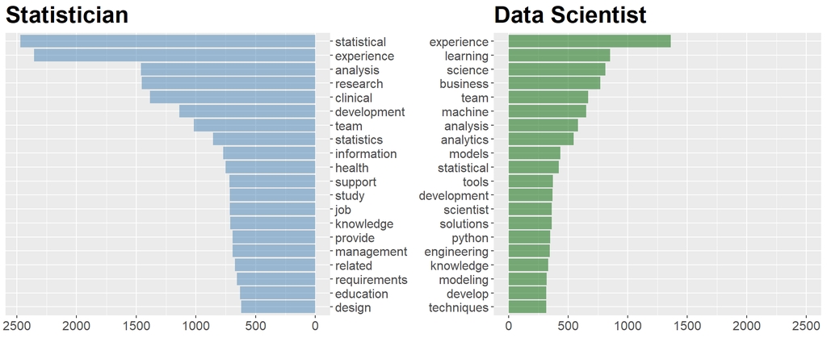

From the plots, we can find that both of them have a high frequency words like experience, analysis and statistical. But also have some special words. For example:  
**Statistician:** Research, management, clinical, design…  
**Data Scientist:** Learning, machine, tools, modeling, techniques…

## Word Cloud

The left one is the cloud of Statistician, the right one is the cloud of Data Scientist.

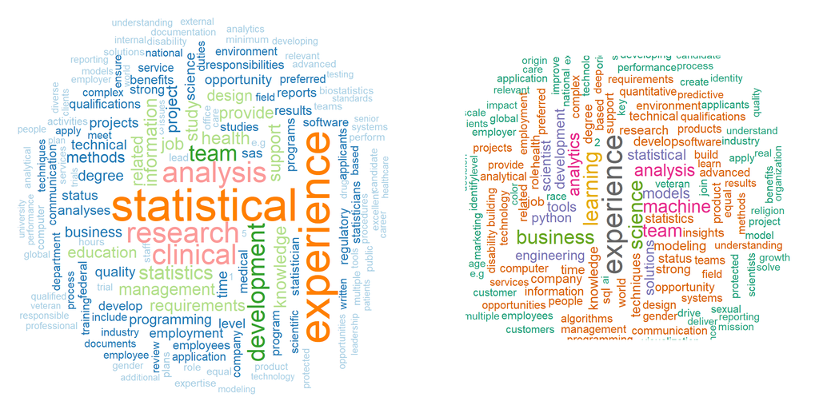

## 2-grams words

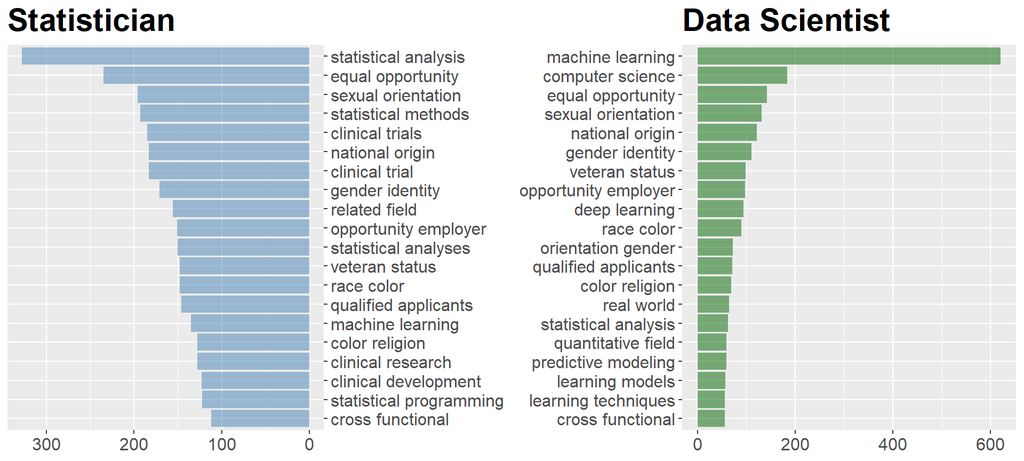

From the 2-grams plots, we can find some special topic in the descriptions. Most of the companies will mention “Opportunity”, “Race”, “Sexual” problems.  
Also, we can tell that **Clinical** will give more “Statistician” title, and may focus on qualified applicants.And “Statistician” will work on methods, research, development…  
But for “Data Scientist”, they are expected to gain “Computer science”, and work on deep learning, modeling…

## Network plots

Also give network plots of these two titles. The left one is for Statistician, and right one is for Data Scientist.

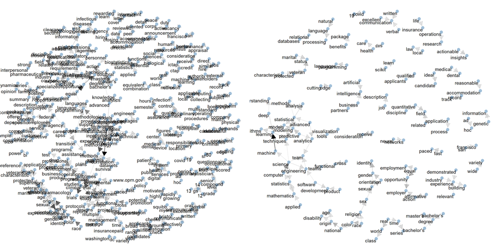

# Question 2: Experience requirement

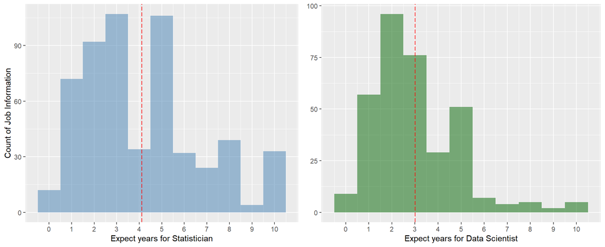

From the plots, we can tell that most of the companies are expected for 1-3 years working experience, but for Statisticians, there is another high expect years, 5 years.

# Question 3: Job location

## State Location

Look at the location distribution, we can find that most of the companies are located at Massachusetts and California.

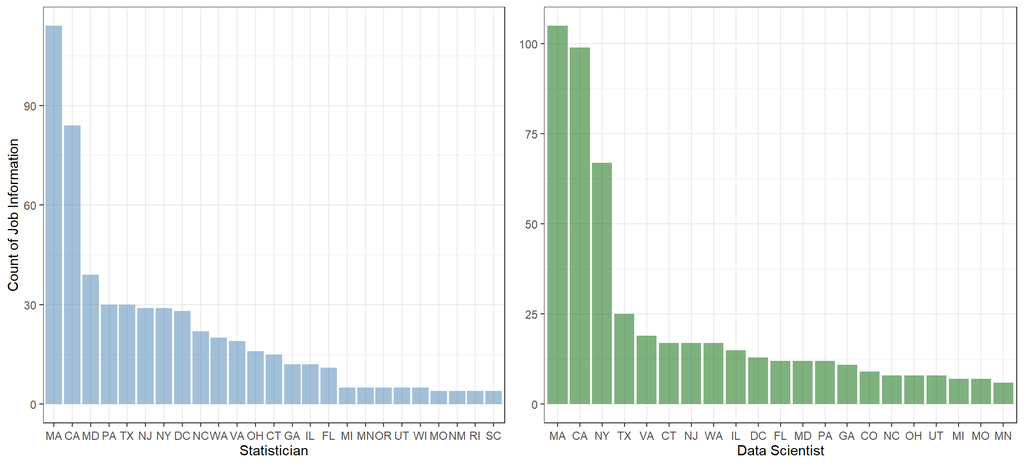

## Look at the city distribution of MA and CA

For statisticians, working opportunities concentrated at Massachusetts, especially Boston.

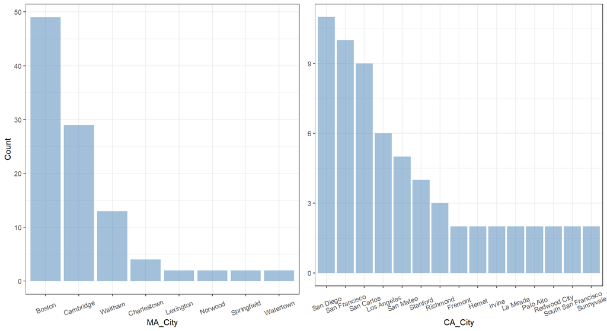

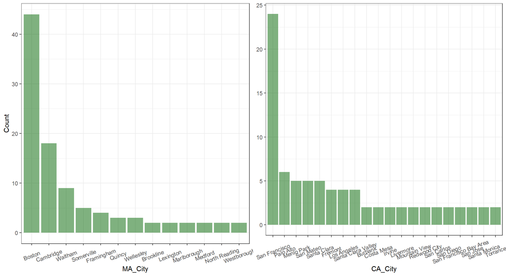

# Question 4: Difference by Location

## Statistician

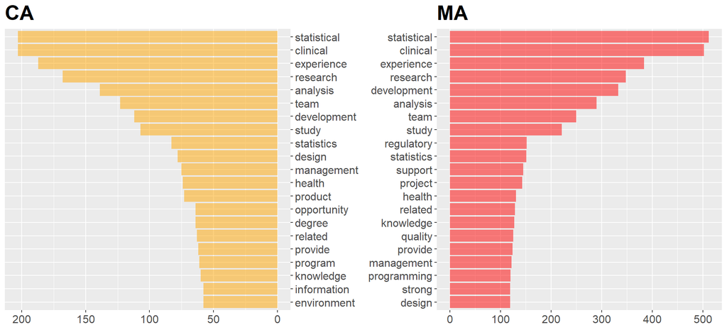

## Data Scientist

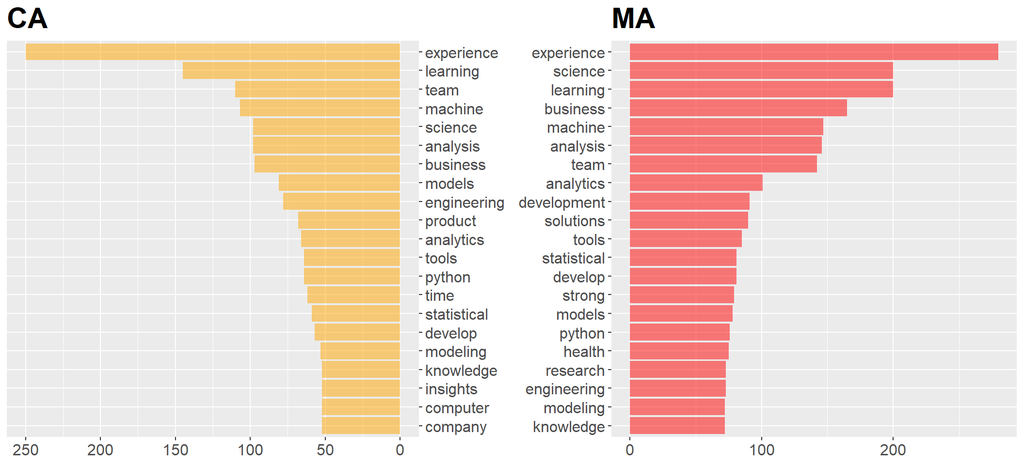

Look at the two plots above, we will tell that there is not a big difference between locations.

# Question 5: Who is providing Data Job

For Statisticians, Natera provided most opportunities, and most of the following companies are health industry companies, like Bristol Myers Squibb, Takeda Pharmaceuticals.

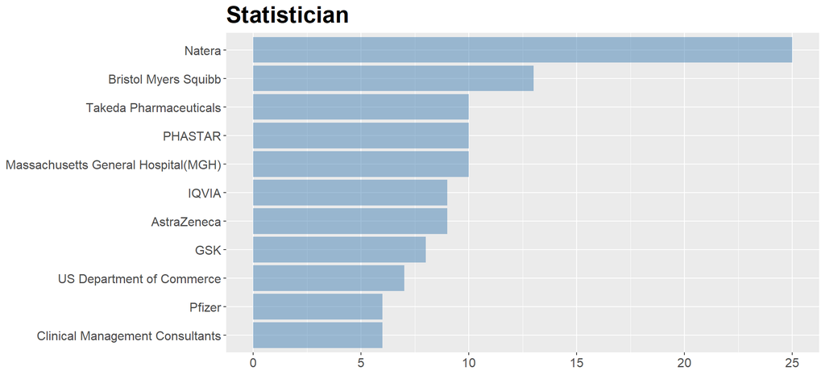

However, except CVS, most of the Data Scientist positions come from technical companies, like Apple, Microsoft and IBM.

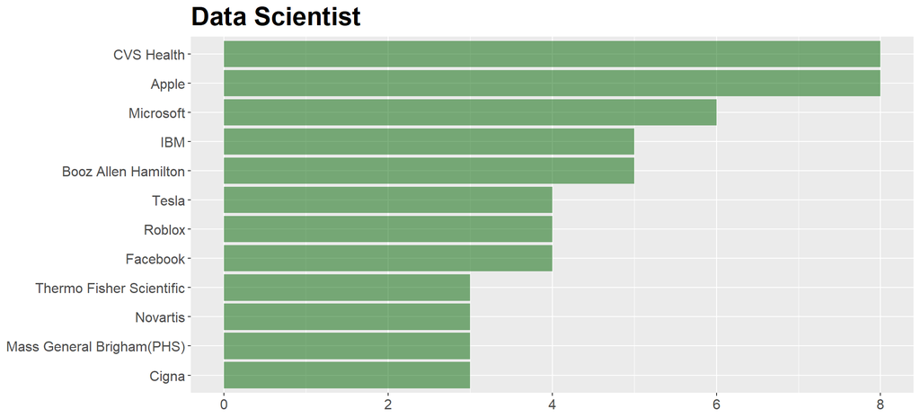

# Look at the Jobs in Map

## Statistician

[interactive chart not shown]

## Data Scientist

[interactive chart not shown]

Note: You can also get Job Details by click the link on the markers in the maps.

# Conclusion

From this project, we can tell that there is difference between Statistician and Data Scientist, including the main industries, required knowledge and skills.

For statisticians, they more going to health industry, or we can say health industry prefer to call “Data Job” as Statistician. While Tech industries will call it Data Scientist.

Also, we can find that the Job vacancy clustered around Massachusetts and California, some in New York. And for statisticians, opportunities concentrated at Massachusetts.

# Reference

1. Data set: [Indeed](https://www.indeed.com/)
2. Longitude and Latitude: [Google Map](https://cloud.google.com/maps-platform/)
3. Text Mining: [Text Mining with R](https://www.tidytextmining.com/)